[figure not shown]

# 1. INTRODUCTION

In this assignment, we aim to evaluate the performance of various machine learning models for predicting outcomes based on a dataset of predictor variables. By comparing models such as Linear Regression, Logistic Regression, Decision Tree, Random Forest, Support Vector Machine, and Neural Network, we seek to understand their strengths, weaknesses, and suitability for different tasks. Through this analysis, we aim to make informed recommendations on model selection based on predictive performance, interpretability, and computational efficiency. This assessment will provide valuable insights into the practical application of machine learning techniques in real-world scenarios.

```python
!pip3 install pandas openpyxl
```

```python
!pip3 install -U gradio
```

```python
!pip3 install -U typing_extensions
```

```python
!pip3 install -U pydantic
```

```python
!pip3 install plotly
!pip3 install statsmodels
!pip3 install seaborn
!pip3 install scikit-learn
```

```python
# Libraries to help on reading and manipulating data
import numpy as np  # See for better reference: https://numpy.org/doc/stable/index.html#
import pandas as pd # See for better reference: https://pandas.pydata.org/


# Libraries to help with data visualization
import matplotlib.pyplot as plt   # Matplotlib is another relevant plotting package.
# It was designed to reproduce the graphical functions of MATLAB in Python.
# See: https://matplotlib.org/
import matplotlib.pyplot as plt
from matplotlib.pyplot import subplots
import seaborn as sns
import plotly.express as px

# Command to tell Python to actually display the graphs
%matplotlib inline

# to restrict the float value to 3 decimal places
pd.set_option('display.float_format', lambda x: '%.3f' % x)

# Helps on better visalization of graphs, based on Seaborn
sns.set()


import statsmodels.api as sm #Statmodels for linear regresion

# Removes the limit for the number of displayed columns
pd.set_option("display.max_columns", None)
# Sets the limit for the number of displayed rows
pd.set_option("display.max_rows", 200)

import pandas as pd
import numpy as np
import matplotlib.pyplot as plt
import seaborn as sns
import plotly.express as px
from sklearn.model_selection import train_test_split
from sklearn.preprocessing import StandardScaler
from sklearn.decomposition import PCA
```

Loading the dataset "Student Retention"

```python
# Loading the dataset. Load the specified sheet into a pandas DataFrame

database = pd.read_excel('/Users/sonuracharla/Downloads/COLLEGE_RET_SV-1 (1).xlsx', sheet_name='DB')
```

```python
database.head()
```

|  | ID | SEMESTER | MAJOR | ESTATUS | GENDER | ORIGIN | FIRSTPART_GRADE | SECONDPARTIAL_GRADE | FINALEXAM_GRADE | FINAL_GRADE | ABSENCES_FIRSTPARTIAL | ABSENCES_SECONDPARTIAL | ABSENCES_THIRDDPARTIAL | NUMCOURSES_ONLINE | SCHOLARSHIP_PERCENT | PASTDUE_BALANCE | NUMBSESSIONS_ADVISORY | NUMBSESSIONS_COUNSELING | TUTORINGMATH_SESSIONS | FORMATIVEPLAN_Q5 | TEACHEREVAL_Q1 | TEACHEREVAL_Q2 | TEACHEREVAL_Q3 | TEACHEREVAL_Q4 | TEACHEREVAL_Q5 | TEACHEREVAL_Q6 | TEACHEREVAL_Q7 | TEACHEREVAL_Q8 | TEACHEREVAL_Q9 | … |
| --- | --- | --- | --- | --- | --- | --- | --- | --- | --- | --- | --- | --- | --- | --- | --- | --- | --- | --- | --- | --- | --- | --- | --- | --- | --- | --- | --- | --- | --- | --- |
| 0 | 398471 | 8 | Business | ENROLLED | FEMALE | Local | 91.286 | 89.286 | 91.714 | 85.429 | 0.000 | 0.714 | 0.000 | 0 | 0.000 | 0.000 | 0 | 0 | 0 | 10 | 7.000 | 7.000 | 7.000 | 6.750 | 6.750 | 7.000 | 6.500 | 7.000 | 7.000 | … |
| 1 | 804181 | 5 | Engineering | ENROLLED | MALE | Local | 89.111 | 92.556 | 92.444 | 91.444 | 0.000 | 0.000 | 0.111 | 0 | 0.500 | 0.000 | 0 | 0 | 0 | 10 | 7.000 | 7.000 | 7.000 | 7.000 | 7.000 | 7.000 | 7.000 | 7.000 | 7.000 | … |
| 2 | 431091 | 1 | Psychology | NOT ENROLLED | FEMALE | Foreign | 98.545 | 96.909 | 98.364 | 99.091 | 0.000 | 0.636 | 0.182 | 0 | 0.450 | 0.000 | 0 | 0 | 0 | 9 | 6.000 | 6.143 | 6.000 | 6.000 | 6.286 | 6.143 | 5.714 | 6.000 | 6.286 | … |
| 3 | 741091 | 6 | Engineering | ENROLLED | FEMALE | Local | 89.556 | 84.889 | 90.778 | 97.444 | 0.444 | 0.111 | 0.222 | 0 | 0.550 | 0.000 | 0 | 0 | 0 | 10 | 7.000 | 7.000 | 7.000 | 7.000 | 7.000 | 7.000 | 7.000 | 7.000 | 7.000 | … |
| 4 | 274091 | 1 | Industrial Design | ENROLLED | FEMALE | Local | 83.300 | 80.200 | 79.800 | 72.000 | 0.100 | 1.100 | 1.300 | 0 | 0.000 | 43320.000 | 0 | 0 | 0 | 10 | 7.000 | 7.000 | 7.000 | 7.000 | 7.000 | 7.000 | 7.000 | 7.000 | 7.000 | … |

```python
database.info()
```

```
<class 'pandas.core.frame.DataFrame'>
RangeIndex: 6597 entries, 0 to 6596
Data columns (total 37 columns):
 #   Column                   Non-Null Count  Dtype
---  ------                   --------------  -----
 0   ID                       6597 non-null   int64
 1   SEMESTER                 6597 non-null   int64
 2   MAJOR                    6597 non-null   object
 3   ESTATUS                  6597 non-null   object
 4   GENDER                   6597 non-null   object
 5   ORIGIN                   6597 non-null   object
 6   FIRSTPART_GRADE          6597 non-null   float64
 7   SECONDPARTIAL_GRADE      6597 non-null   float64
 8   FINALEXAM_GRADE          6597 non-null   float64
 9   FINAL_GRADE              6597 non-null   float64
```

[output cut: 29 more lines]

## Dataset Overview

```python
# checking shape of the data
print("There are", database.shape[0], 'rows and', database.shape[1], "columns.")
```

```
There are 6597 rows and 37 columns.
```

```python
# Define the variables and their properties based on the image provided
variables_info = {
    'Variable Name': [
        'ID', 'SEMESTER', 'MAJOR', 'ESTATUS', 'GENDER', 'ORIGIN', 'FIRSTPART_GRADE',
        'SECONDPARTIAL_GRADE', 'FINALEXAM_GRADE', 'FINAL_GRADE', 'ABSENCES_FIRSTPARTIAL',
        'ABSENCES_SECONDPARTIAL', 'ABSENCES_THIRDDPARTIAL', 'NUMCOURSES_ONLINE',
        'SCHOLARSHIP_PERCENT', 'PASTDUE_BALANCE', 'NUMBSESSIONS_ADVISORY',
        'NUMBSESSIONS_COUNSELING', 'TUTORINGMATH_SESSIONS', 'FORMATIVEPLAN_Q5',
        'TEACHEREVAL_Q1', 'TEACHEREVAL_Q2', 'TEACHEREVAL_Q3', 'TEACHEREVAL_Q4',
        'TEACHEREVAL_Q5', 'TEACHEREVAL_Q6', 'TEACHEREVAL_Q7', 'TEACHEREVAL_Q8',
        'TEACHEREVAL_Q9', 'TEACHEREVAL_Q10', 'TEACHEREVAL_Q11', 'TEACHEREVAL_Q12',
        'TEACHEREVAL_Q13', 'TEACHEREVAL_Q14', 'TEACHEREVAL_Q15', 'TEACHEREVAL_Q16',
        'HONOR_FAULTS'
    ],
    'Measurement Type': [
        'Nominal', 'Ordinal', 'Nominal', 'Nominal', 'Nominal', 'Nominal', 'Scale',
        'Scale', 'Scale', 'Scale', 'Ratio', 'Ratio', 'Ratio', 'Ratio',
        'Ratio', 'Ratio', 'Ratio', 'Ratio', 'Ratio', 'Ordinal',
        'Ordinal', 'Ordinal', 'Ordinal', 'Ordinal', 'Ordinal', 'Ordinal', 'Ordinal',
        'Ordinal', 'Ordinal', 'Ordinal', 'Ordinal', 'Ordinal', 'Ordinal', 'Ordinal',
        'Ordinal', 'Ordinal', 'Ratio'
    ],
    'Role of the Variable': [
        'Excluded', 'Predictor', 'Predictor', 'Predictor', 'Predictor', 'Predictor', 'Outcome',
        'Outcome', 'Outcome', 'Outcome', 'Predictor', 'Predictor', 'Predictor', 'Predictor',
        'Predictor', 'Predictor', 'Predictor', 'Predictor', 'Predictor', 'Predictor',
        'Predictor', 'Predictor', 'Predictor', 'Predictor', 'Predictor', 'Predictor', 'Predictor',
        'Predictor', 'Predictor', 'Predictor', 'Predictor', 'Predictor', 'Predictor', 'Predictor',
        'Predictor', 'Predictor', 'Outcome'
    ]
}

# Create a DataFrame with the above information
variables_table = pd.DataFrame(variables_info)
```

```python
print(variables_table)
```

```
              Variable Name Measurement Type Role of the Variable
0                        ID          Nominal             Excluded
1                  SEMESTER          Ordinal            Predictor
2                     MAJOR          Nominal            Predictor
3                   ESTATUS          Nominal            Predictor
4                    GENDER          Nominal            Predictor
5                    ORIGIN          Nominal            Predictor
6           FIRSTPART_GRADE            Scale              Outcome
7       SECONDPARTIAL_GRADE            Scale              Outcome
8           FINALEXAM_GRADE            Scale              Outcome
9               FINAL_GRADE            Scale              Outcome
10    ABSENCES_FIRSTPARTIAL            Ratio            Predictor
11   ABSENCES_SECONDPARTIAL            Ratio            Predictor
12   ABSENCES_THIRDDPARTIAL            Ratio            Predictor
13        NUMCOURSES_ONLINE            Ratio            Predictor
```

[output cut: 23 more lines]

# 2. Exploratory Analysis

## Getting to Know the Data:

Exploratory Data Analysis is our first step in uncovering the secrets within our dataset.

## Getting Acquainted with the Data

Let's familiarize ourselves with the data structure and the type of information we have.

```python
# Print the current columns in the DataFrame
print(database.columns)
```

```
Index(['ID', 'SEMESTER', 'MAJOR', 'ESTATUS', 'GENDER', 'ORIGIN',
       'FIRSTPART_GRADE', 'SECONDPARTIAL_GRADE', 'FINALEXAM_GRADE',
       'FINAL_GRADE', 'ABSENCES_FIRSTPARTIAL', 'ABSENCES_SECONDPARTIAL',
       'ABSENCES_THIRDDPARTIAL', 'NUMCOURSES_ONLINE', 'SCHOLARSHIP_PERCENT',
       'PASTDUE_BALANCE', 'NUMBSESSIONS_ADVISORY', 'NUMBSESSIONS_COUNSELING',
       'TUTORINGMATH_SESSIONS', 'FORMATIVEPLAN_Q5', 'TEACHEREVAL_Q1',
       'TEACHEREVAL_Q2', 'TEACHEREVAL_Q3', 'TEACHEREVAL_Q4', 'TEACHEREVAL_Q5',
       'TEACHEREVAL_Q6', 'TEACHEREVAL_Q7', 'TEACHEREVAL_Q8', 'TEACHEREVAL_Q9',
       'TEACHEREVAL_Q10', 'TEACHEREVAL_Q11', 'TEACHEREVAL_Q12',
       'TEACHEREVAL_Q13', 'TEACHEREVAL_Q14', 'TEACHEREVAL_Q15',
       'TEACHEREVAL_Q16', 'HONOR_FAULTS'],
      dtype='object')
```

```python
# Displaying the initial rows of our dataset for a preliminary look
print(database.head())

# Understanding the data types we have and checking for missing values
database.info()

# Statistical summary to grasp the numerical data's distribution
print(database.describe())
```

```
       ID  SEMESTER              MAJOR       ESTATUS  GENDER   ORIGIN  \
0  398471         8           Business      ENROLLED  FEMALE    Local
1  804181         5        Engineering      ENROLLED    MALE    Local
2  431091         1         Psychology  NOT ENROLLED  FEMALE  Foreign
3  741091         6        Engineering      ENROLLED  FEMALE    Local
4  274091         1  Industrial Design      ENROLLED  FEMALE    Local

   FIRSTPART_GRADE  SECONDPARTIAL_GRADE  FINALEXAM_GRADE  FINAL_GRADE  \
0           91.286               89.286           91.714       85.429
1           89.111               92.556           92.444       91.444
2           98.545               96.909           98.364       99.091
3           89.556               84.889           90.778       97.444
4           83.300               80.200           79.800       72.000

   ABSENCES_FIRSTPARTIAL  ABSENCES_SECONDPARTIAL  ABSENCES_THIRDDPARTIAL  \
0                  0.000                   0.714                   0.000
1                  0.000                   0.000                   0.111
2                  0.000                   0.636                   0.182
3                  0.444                   0.111                   0.222
4                  0.100                   1.100                   1.300

   NUMCOURSES_ONLINE  SCHOLARSHIP_PERCENT  PASTDUE_BALANCE  \
0                  0                0.000            0.000
1                  0                0.500            0.000
2                  0                0.450            0.000
3                  0                0.550            0.000
4                  0                0.000        43320.000

   NUMBSESSIONS_ADVISORY  NUMBSESSIONS_COUNSELING  TUTORINGMATH_SESSIONS  \
0                      0                        0                      0
1                      0                        0                      0
2                      0                        0                      0
3                      0                        0                      0
4                      0                        0                      0

   FORMATIVEPLAN_Q5  TEACHEREVAL_Q1  TEACHEREVAL_Q2  TEACHEREVAL_Q3  \
0                10           7.000           7.000           7.000
1                10           7.000           7.000           7.000
2                 9           6.000           6.143           6.000
3                10           7.000           7.000           7.000
```

[output cut: 157 more lines]

```
min              1.000            1.000            1.000            1.000
25%              6.667            6.667            6.714            7.000
50%              7.000            7.000            7.000            7.000
75%              7.000            7.000            7.000            7.000
max              7.000            7.000            7.000            7.000

       HONOR_FAULTS
count      6597.000
mean          0.014
std           0.125
min           0.000
25%           0.000
50%           0.000
75%           0.000
max           3.000
```

## Visualization for a Deeper Understanding

Graphical representations can reveal patterns and insights more intuitively.

Investigating Individual Variables We start by examining each variable individually to understand its distribution and characteristics.

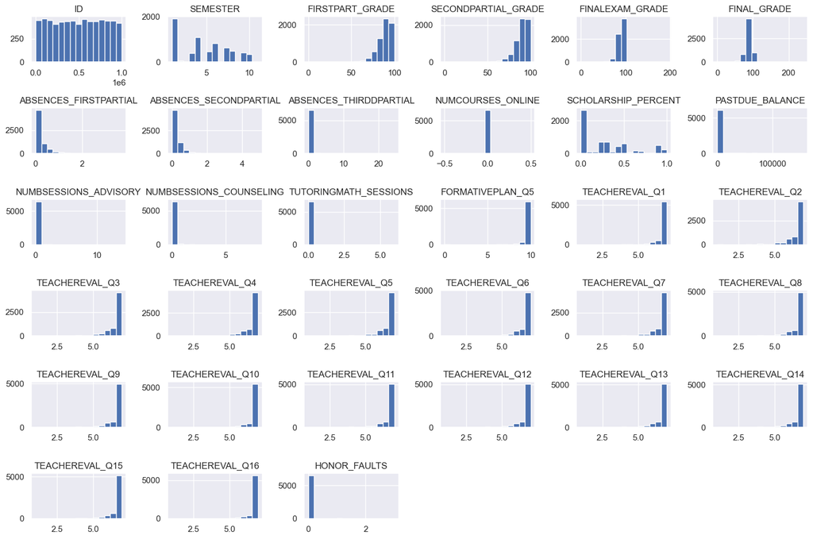

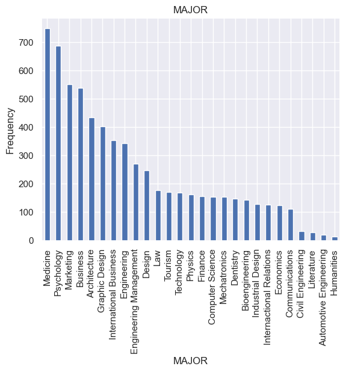

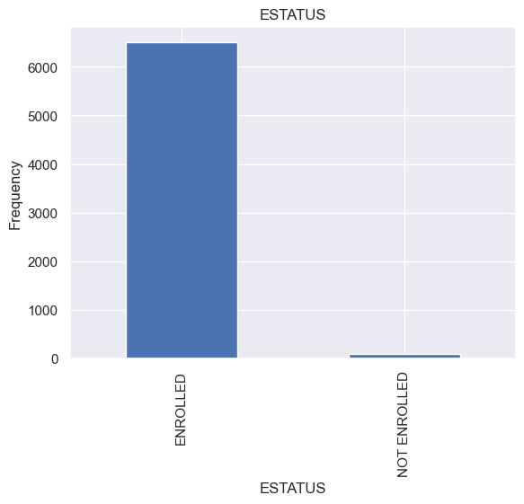

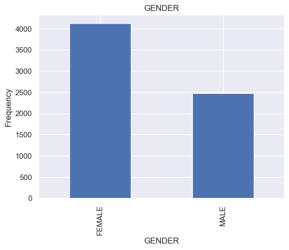

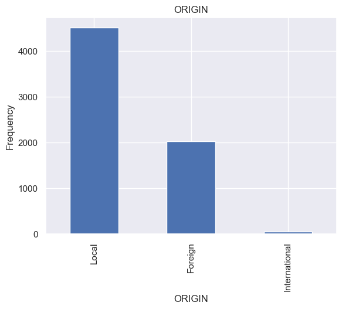

```python
import matplotlib.pyplot as plt

# Visualizing distributions of all numerical variables
database.hist(bins=15, figsize=(15, 10))
plt.tight_layout()  # Adjusts subplots to fit into the figure area.
plt.show()

# Creating bar charts for the categorical variables to understand their distribution
categorical_columns = database.select_dtypes(include=['object', 'category']).columns
for column in categorical_columns:
    database[column].value_counts().plot(kind='bar', title=column)
    plt.ylabel('Frequency')
    plt.show()
```

### Exploring Relationships Between Variables

Understanding how variables relate to each other and to the target variable is crucial.

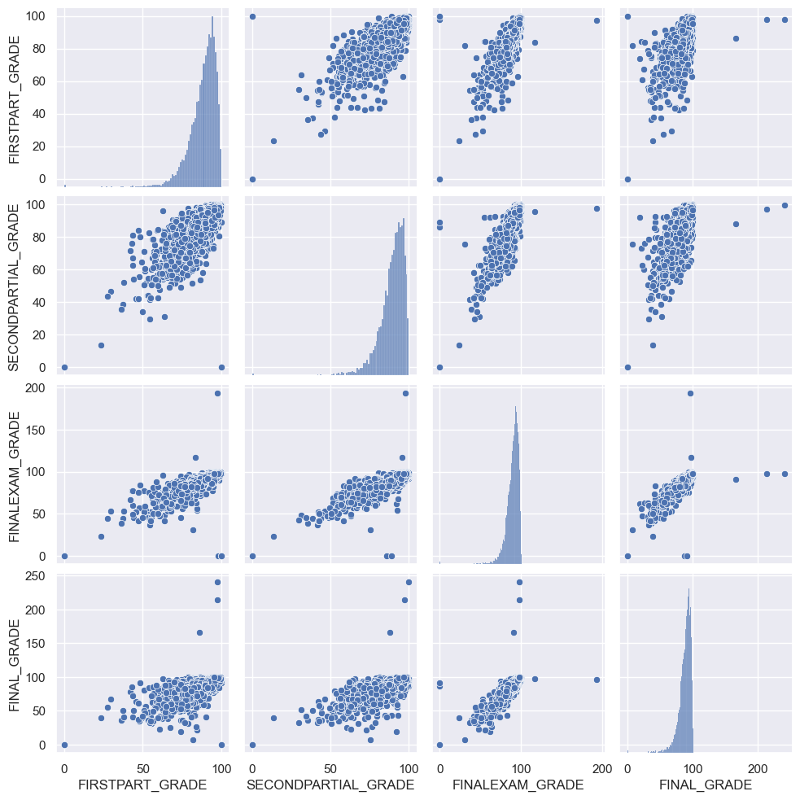

```python
import pandas as pd
import numpy as np
import seaborn as sns
import matplotlib.pyplot as plt
import warnings

# Suppress future warnings
warnings.simplefilter(action='ignore', category=FutureWarning)

database.replace([np.inf, -np.inf], np.nan, inplace=True)

# Selecting a subset of numerical columns relevant to academic performance
interested_numerical_columns = ['FIRSTPART_GRADE', 'SECONDPARTIAL_GRADE', 'FINALEXAM_GRADE', 'FINAL_GRADE']

# Generate a pair plot for the selected subset of columns
sns.pairplot(database[interested_numerical_columns])
plt.show()
```

[figure not shown]

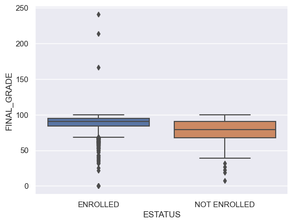

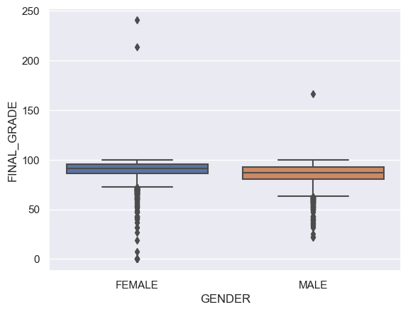

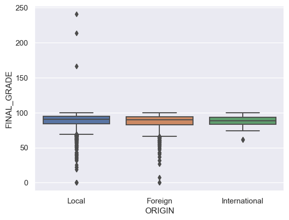

```python
# Box plots to examine how numerical features vary with different categories
for column in categorical_columns:
    sns.boxplot(x=column, y='FINAL_GRADE', data=database)
# Replace 'TargetVariable' with your actual outcome column
    plt.show()
```

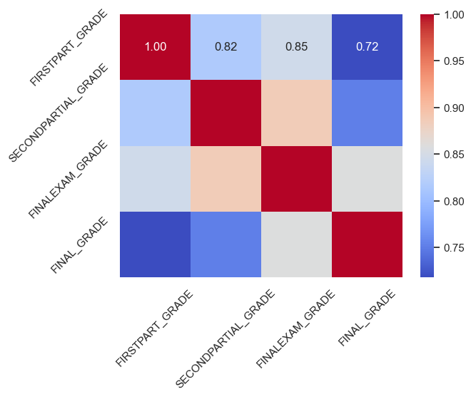

```python
# Selecting a subset of columns for the correlation matrix
columns_of_interest = ['FIRSTPART_GRADE', 'SECONDPARTIAL_GRADE', 'FINALEXAM_GRADE', 'FINAL_GRADE']
subset_corr = database[columns_of_interest].corr()

# Creating a heatmap for the subset
sns.heatmap(subset_corr, annot=True, cmap='coolwarm', fmt=".2f")
plt.xticks(rotation=45)  # Rotate x-axis labels for better readability
plt.yticks(rotation=45)  # Rotate y-axis labels for better readability
plt.show()
```

### Addressing Missing Values

Handling missing data is vital for maintaining the integrity of our analysis.

```python
# Identifying missing values across the dataset
print(database.isnull().sum())
```

```
ID                         0
SEMESTER                   0
MAJOR                      0
ESTATUS                    0
GENDER                     0
ORIGIN                     0
FIRSTPART_GRADE            0
SECONDPARTIAL_GRADE        0
FINALEXAM_GRADE            0
FINAL_GRADE                0
ABSENCES_FIRSTPARTIAL      0
ABSENCES_SECONDPARTIAL     0
ABSENCES_THIRDDPARTIAL     0
NUMCOURSES_ONLINE          0
SCHOLARSHIP_PERCENT        0
PASTDUE_BALANCE            0
NUMBSESSIONS_ADVISORY      0
NUMBSESSIONS_COUNSELING    0
TUTORINGMATH_SESSIONS      0
FORMATIVEPLAN_Q5           0
TEACHEREVAL_Q1             0
TEACHEREVAL_Q2             0
TEACHEREVAL_Q3             0
TEACHEREVAL_Q4             0
TEACHEREVAL_Q5             0
TEACHEREVAL_Q6             0
TEACHEREVAL_Q7             0
TEACHEREVAL_Q8             0
TEACHEREVAL_Q9             0
TEACHEREVAL_Q10            0
TEACHEREVAL_Q11            0
TEACHEREVAL_Q12            0
TEACHEREVAL_Q13            0
TEACHEREVAL_Q14            0
TEACHEREVAL_Q15            0
TEACHEREVAL_Q16            0
HONOR_FAULTS               0
dtype: int64
```

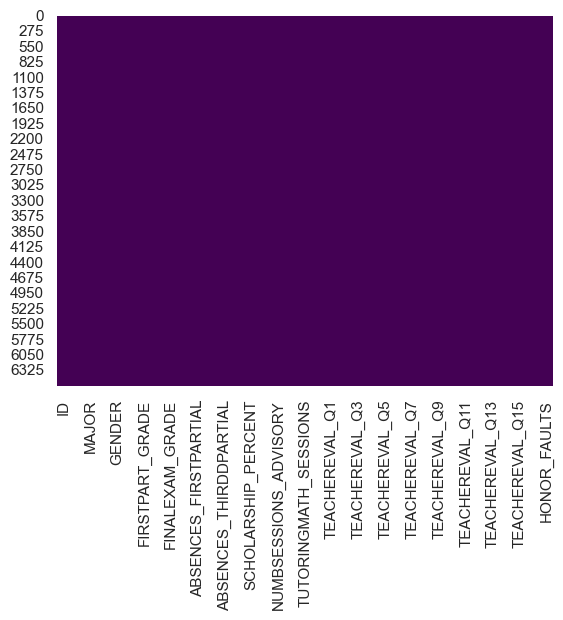

```python
# Optional: Visualizing the distribution of missing values
sns.heatmap(database.isnull(), cbar=False, cmap='viridis')
plt.show()
```

### Outlier Detection and Treatment

Outliers can significantly affect our models and analyses, so it's important to identify and decide how to handle them.

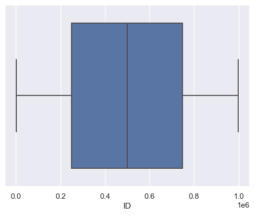

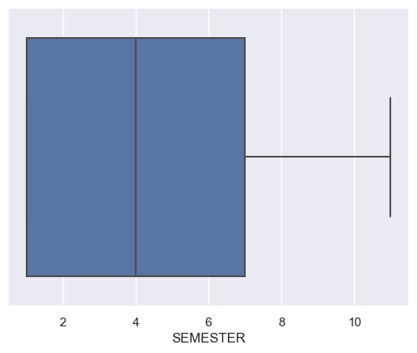

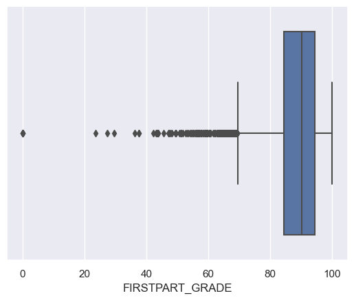

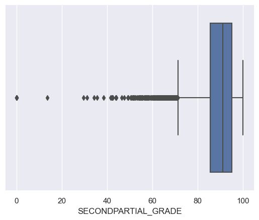

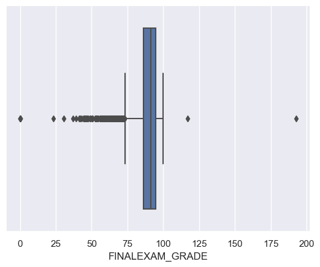

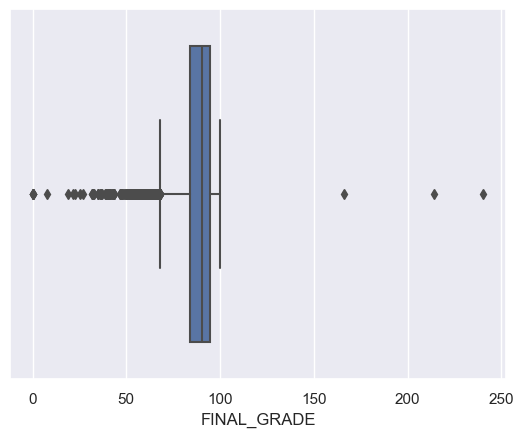

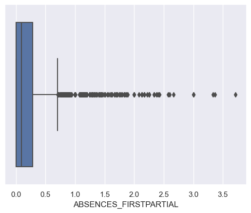

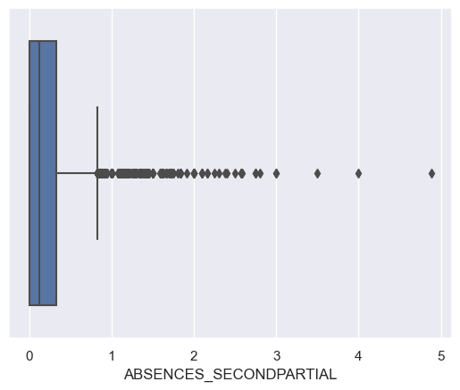

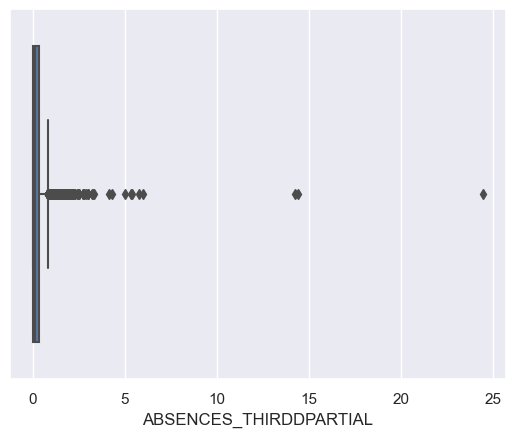

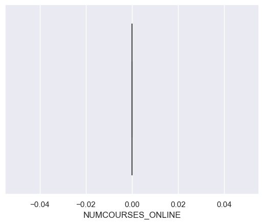

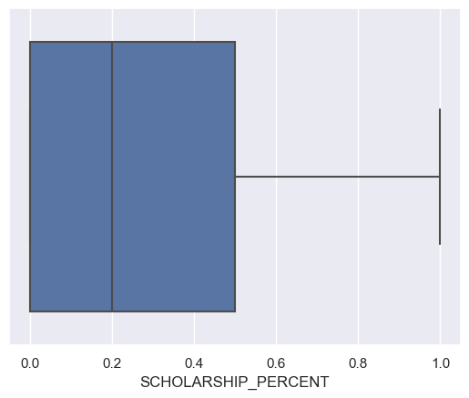

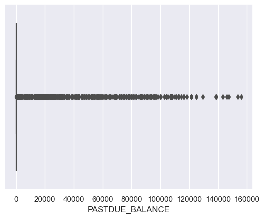

[21 more figures not shown]

```python
# Utilizing box plots to spot outliers in numerical columns
for column in database.select_dtypes(include=['float64', 'int64']).columns:
    sns.boxplot(x=database[column])
    plt.show()
```

### Preparing Data for Modeling

Building predictive models is a crucial step in analyzing data, where machine learning algorithms are applied to learn from the features of the dataset and make predictions. This process involves setting up different models, tuning their parameters, and evaluating their performance. Let's break down the steps involved:

### Splitting the Data for Training and Testing

Before building models, it's essential to split the data into training and testing sets. This ensures that the model's performance can be evaluated on unseen data.

### Encoding Categorical Variables and Scaling

Many models require numerical input and benefit from features being on a similar scale.

```python
from sklearn.model_selection import train_test_split
from sklearn.preprocessing import StandardScaler, OneHotEncoder
from sklearn.compose import ColumnTransformer

# Splitting the data into features (X) and target variable (y)
X = database.drop('FINAL_GRADE', axis=1)
y = database['FINAL_GRADE']

# Splitting the data into training and testing sets
X_train, X_test, y_train, y_test = train_test_split(X, y, test_size=0.2, random_state=42)

# Identifying categorical and numerical columns
categorical_cols = X_train.select_dtypes(include=['object', 'category']).columns
numerical_cols = X_train.select_dtypes(include=['float64', 'int64']).columns

# Creating transformers for scaling and encoding
preprocessor = ColumnTransformer(
    transformers=[
        ('num', StandardScaler(), numerical_cols),
        ('cat', OneHotEncoder(), categorical_cols)
    ]
)

# Apply preprocessing to training data
X_train_processed = preprocessor.fit_transform(X_train)

# Apply preprocessing to testing data
X_test_processed = preprocessor.transform(X_test)
```

# 3. Building predictive models

## Parametric models:

### Model 1: Linear Regression

Linear Regression is a fundamental model for predicting continuous numerical values. It's a simple yet powerful method used for regression tasks

```python
from sklearn.linear_model import LinearRegression
from sklearn.metrics import mean_squared_error

# Initialize the model
linear_reg = LinearRegression()

# Train the model
linear_reg.fit(X_train_processed, y_train)

# Predict on the testing set
y_pred_linear_reg = linear_reg.predict(X_test_processed)

# Evaluate the model
mse = mean_squared_error(y_test, y_pred_linear_reg)
print(f'Linear Regression Mean Squared Error: {mse}')
```

```
Linear Regression Mean Squared Error: 37.56267750312221
```

### Model 2: linear regression model with LASSO.

```python
from sklearn.linear_model import Lasso

# Initialize the model with Lasso regularization
lasso_reg = Lasso(alpha=0.1)  # You can adjust the alpha parameter for the level of regularization

# Train the model
lasso_reg.fit(X_train_processed, y_train)

# Predict on the testing set
y_pred_lasso_reg = lasso_reg.predict(X_test_processed)

# Evaluate the model
mse_lasso = mean_squared_error(y_test, y_pred_lasso_reg)
print(f'Lasso Regression Mean Squared Error: {mse_lasso}')
```

```
Lasso Regression Mean Squared Error: 33.96658633943958
```